# SARS-CoV-2 Variants Coinfection

February 10, 2025

## **Lineage assignment**

### Pangolin and Nextclade

Lineage assigment table using Pangolin and Nextclade of all samples.

| Sample | Coverage | Pangolin | Scorpio | Nextclade | WHO clade | Note |
| --- | --- | --- | --- | --- | --- | --- |
| AY.75_10_BA.2.5_90 | 99.02% | BA.2.5 | Probable Omicron (Unassigned) | BA.2.5 | Omicron | Usher placements: BA.2.5(1/1); scorpio found insufficient support to assign a specific lineage |
| AY.75_5_BA.2.5_95 | 99.2% | BA.2.5 | Omicron (BA.2-like) | BA.2.5 | Omicron | Assigned from designation hash. |
| AY.75_20_BA.2.5_80 | 98.94% | BA.2 | NA | BA.2 | Omicron | Usher placements: BA.2(2/2) |
| AY.75_2_BA.2.5_98 | 99.2% | BA.2.5 | Omicron (BA.2-like) | BA.2.5 | Omicron | Assigned from designation hash. |
| AY.75_50_BA.2.5_50 | 98.93% | BA.2 | NA | BA.2 | Omicron | Usher placements: BA.2(2/2) |

### Freyja

The Freyja plot shows the relative SARS-CoV-2 lineage abundance in each sample. Samples suspect for coinfection will illustrate mixed prevalence of two or more variants.

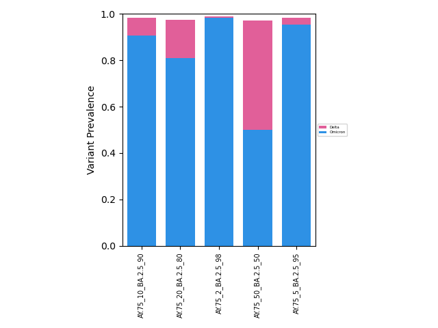

### VirStrain

Suspected coinfection samples were analyzed using the VirStrain tool against a database of representative SARS-CoV-2 sequences. The results are summarized in the table below, where the ‘Most Possible Strain’ represents the lineage with the highest Vscore in the initial iteration. Meanwhile, the ‘Other Possible Strain’ is identified by the highest Vscore in subsequent iterations and is considered highly supported if the ‘Valid Map Rate’ is 10 or more mutations, as outlined by Liao et al. (2022).

| Sample | Most Possible Strain | Other Possible Strain | Valid Map Rate |
| --- | --- | --- | --- |
| AY.75_10_BA.2.5_90 | Omicron_BA.2 | B.1.617.2 | 7/93 |
| AY.75_20_BA.2.5_80 | Omicron_BA.2 | B.1.617.2 | 8/93 |
| AY.75_2_BA.2.5_98 | Omicron_BA.2 | Can not detect other strains. | NA |
| AY.75_50_BA.2.5_50 | Omicron_BA.2 | B.1.617.2 | 8/93 |
| AY.75_5_BA.2.5_95 | Omicron_BA.2 | B.1.617.2 | 6/93 |

## **Nucleotide mixture per position**

The figure below shows the Bammix plot for nucleotide mixtures of the sample/s with potential SARS-CoV-2 variants coinfection. Multiple sites containing heterogenous bases crossing the threshold of >20% mixture will be apparent.

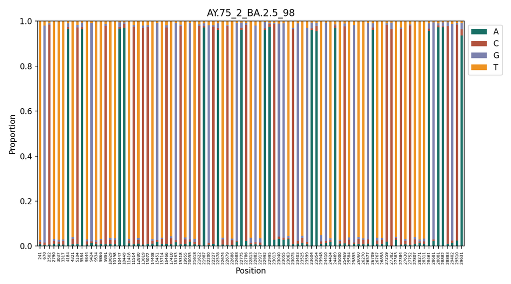

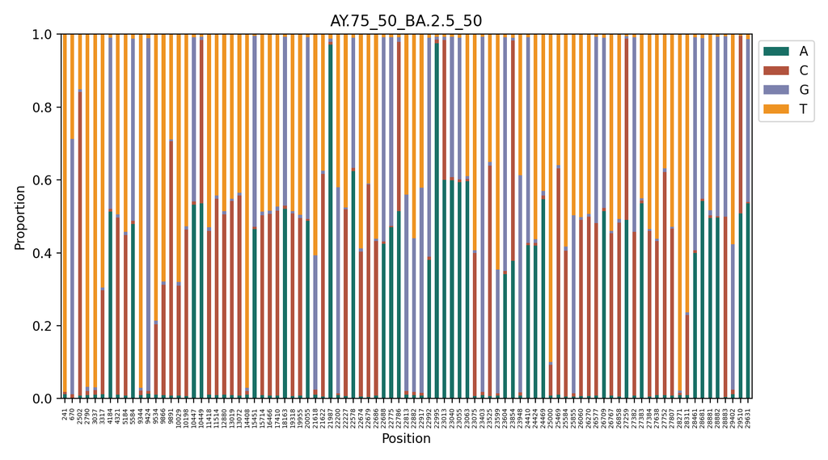

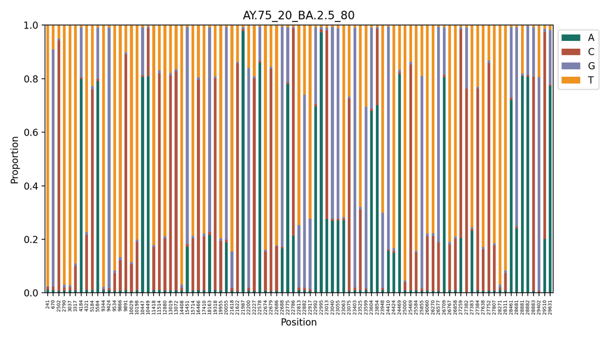

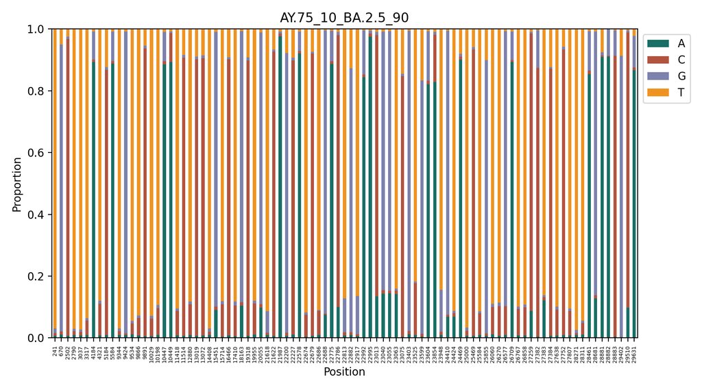

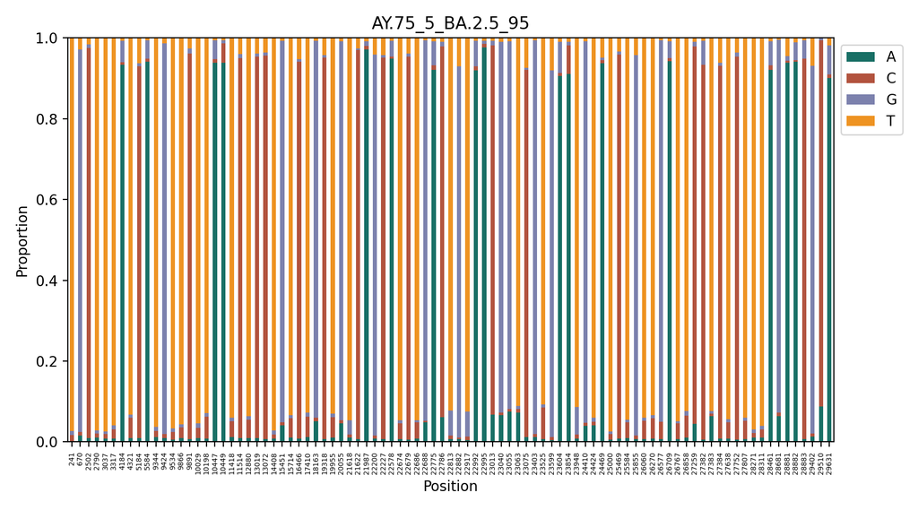

## **Alternative allele fraction**

### For each lineage-defining mutations

The alternative allele fraction (AAF) determines the number of reads supporting each variant detected in the sample/s. The AAF per mutation of sample/s flagged for SARS-CoV-2 coinfection are shown in the figure. Delta, Omicron, and shared mutations are represented by blue, pink, and purple, respectively.

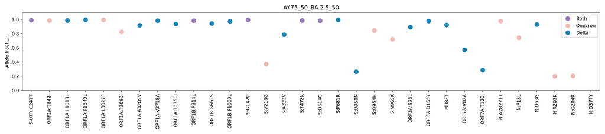

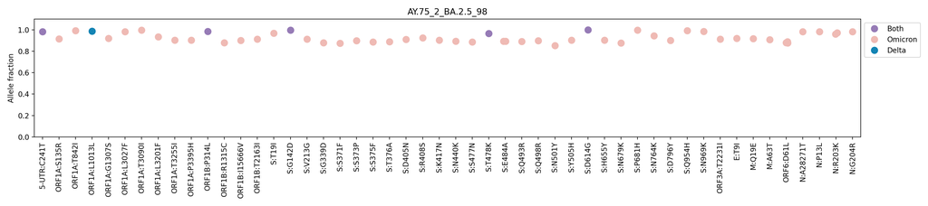

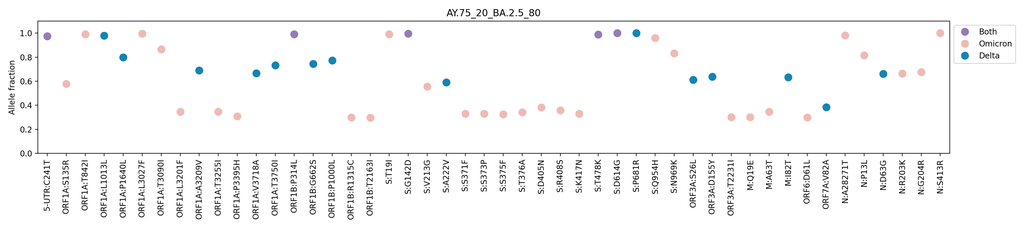

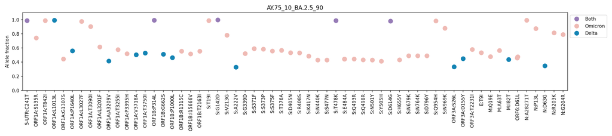

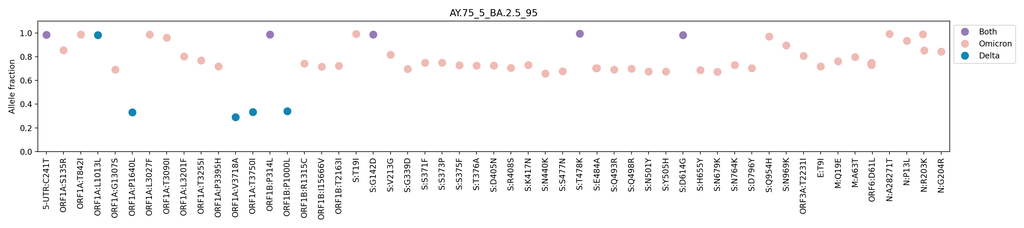

### For each amplicon

The AAF for each amplicon is plotted by getting the average allele fraction for Delta and Omicron defining mutation within the range of that amplicon.

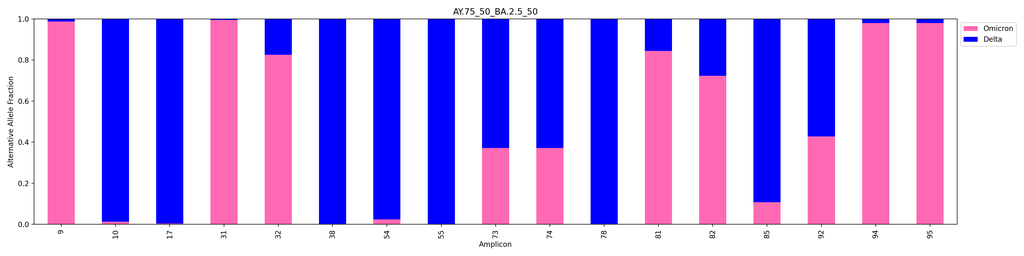

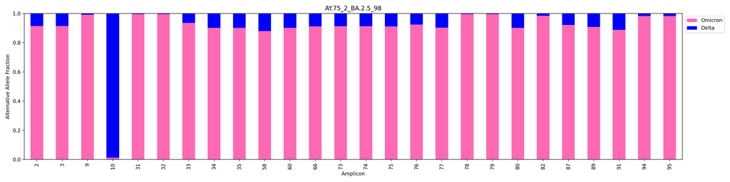

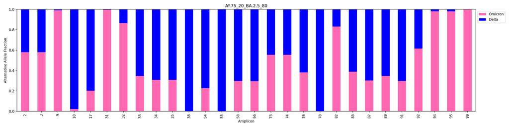

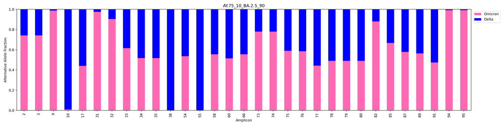

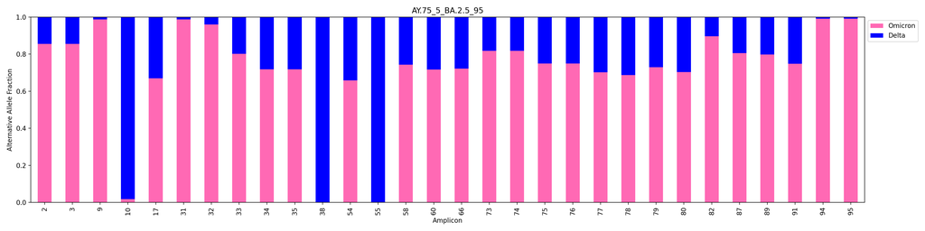

## **References**

### Pipeline

The tools used in this [pipeline](https://github.com/lanadelrea/CoPi) are as follows:

- [Pangolin](https://github.com/cov-lineages/pangolin)
- [Nextclade](https://github.com/nextstrain/nextclade)
- Freyja
- VirStrain
- [Bammix](https://github.com/chrisruis/bammix)
- Custom scripts adopted from [Bolze et al.](https://doi.org/10.1016/j.medj.2022.10.002)